# 12 Supervised learning with support Vector Machines

# Introduction

Support Vector Machines (SVMs) are a powerful class of supervised learning algorithms used for classification and regression. They aim to find the hyperplane which best divides a dataset into classes. This method is particularly useful when the classes are not linearly separable. The beauty of SVMs lies in their utilization of geometry and the introduction of the kernel trick to handle non-linear data.

A Support Vector Machine is a supervised learning model that creates a hyperplane or set of hyperplanes in a high- or infinite-dimensional space, which can be used for classification, regression, or other tasks. The main goal is to separate the data in such a way that the margin between the two classes is maximized.

# Prepare the workspace

```r
options(
  digits = 2,
  scipen = 999,
  warn = -1
)
rm(
  list = ls()
)
library(magrittr)
```

## The Concept of Margin

The margin is defined as the distance between the separating hyperplane and the nearest data point from either class. An SVM aims to maximize this margin, ensuring robustness and generalizability of the classification.

Given a hyperplane defined by:
$$w \cdot
x + b = 0$$

The distance of a point $x_i$ to this hyperplane is:
$$\frac{|w \cdot x_i +
b|}{\| w \|}$$

## Hard vs Soft Margin

- **Hard Margin SVM**: Assumes that the data is linearly separable and tries to find the hyperplane without any misclassification. This can lead to overfitting in the presence of noise.
- **Soft Margin SVM**: Allows some misclassifications in the hope of achieving a more generalizable model. This is controlled by a parameter, often called $C$.

```r
M_mushrooms <- readr::read_csv(
  file = "/Users/thienpham/Data Mining/data/prepared_mushrooms.csv",
  col_types = "cnnnnnnnnnnnnnnnnnnnnnn"
) %>%
  dplyr::mutate(
    train_test = ifelse(runif(dplyr::n()) > 0.5,"Train","Test")
  ) %>%
  as.data.frame()
```

# Kernel Trick

While SVM is linear by design, the Kernel trick allows it to work on non-linearly separable data. It does so by mapping the data into a higher-dimensional space, making it possible to find a hyperplane that separates the data.

$$K(x_i, x_j) = \phi(x_i) \cdot \phi(x_j)$$

Popular kernels include: - Linear: $K(x, y) = x \cdot y$ - Polynomial: $K(x, y) = (1 + x \cdot y)^d$ - Radial basis function (RBF): $K(x, y) = \exp(-\gamma \|x - y\|^2)$

# What is a support vector machine kernel?

In the context of Support Vector Machines (SVMs), a **kernel** is a function that computes the dot product between two vectors in a transformed space. Instead of explicitly transforming the vectors into this higher-dimensional space and then calculating the dot product, the kernel provides a shortcut by directly computing the dot product in the original space, which can often be computationally more efficient.

The kernel essentially allows SVMs to create non-linear decision boundaries without explicitly transforming the data.

Here’s a breakdown of the kernel’s significance:

1. **Linearity & Non-linearity**: SVMs, in their basic form, construct a linear hyperplane to separate data. But, real-world data is often not linearly separable. Kernels help SVMs deal with such non-linear data by implicitly mapping the data into a higher-dimensional space where it becomes linearly separable.
2. **Types of Kernels**:
   - **Linear Kernel**: Represents a linear decision boundary. Mathematically, it’s just the dot product of the two input vectors.

**** There are 2 methods to do this, the caret package which invokes kernlab and doing it in kernlab directly.

```r
train_svmLinear <- caret::train(
  x = M_mushrooms %>%
    dplyr::filter(train_test == "Train") %>%
    dplyr::select(
      odor,spore_print_color,ring_type,gill_color,gill_size
    ) %>%
    as.data.frame(),
  y = M_mushrooms %>%
    dplyr::filter(train_test == "Train") %>%
    dplyr::mutate(class = factor(class,levels = c("p","e"))) %>%
    dplyr::pull(class),
  method = "svmLinear"
)
train_svmLinear
```

```
## Support Vector Machines with Linear Kernel
##
## 4000 samples
##    5 predictor
##    2 classes: 'p', 'e'
##
## No pre-processing
## Resampling: Bootstrapped (25 reps)
## Summary of sample sizes: 4000, 4000, 4000, 4000, 4000, 4000, ...
## Resampling results:
##
##   Accuracy  Kappa
##   0.99      0.97
##
## Tuning parameter 'C' was held constant at a value of 1
```

```r
print("--- Using kernlab directly --------------------------------------------")
```

```
## [1] "--- Using kernlab directly --------------------------------------------"
```

```r
kernlab::ksvm(
  x = M_mushrooms %>%
    dplyr::filter(train_test == "Train") %>%
    dplyr::select(
      odor,spore_print_color,ring_type,gill_color,gill_size
    ) %>%
    as.matrix(), #kernlab doesnt like dataframes they want matrices
  y = M_mushrooms %>%
    dplyr::filter(train_test == "Train") %>%
    dplyr::mutate(class = factor(class,levels = c("p","e"))) %>%
    dplyr::select(class) %>%
    as.data.frame(),
  kernel = "vanilladot"
)
```

```
## Support Vector Machine object of class "ksvm"
##
## SV type: C-svc  (classification)
##  parameter : cost C = 1
##
## Linear (vanilla) kernel function.
##
## Number of Support Vectors : 130
##
## Objective Function Value : -122
## Training error : 0.01525
```

- **Polynomial Kernel**: Introduces polynomial decision boundaries (e.g., curves, parabolas). The degree of the polynomial determines the complexity of the decision boundary.

```r
train_svmPoly <- caret::train(
  x = M_mushrooms %>%
    dplyr::filter(train_test == "Train") %>%
    dplyr::select(
      odor,spore_print_color,ring_type,gill_color,gill_size
    ),
  y = M_mushrooms %>%
    dplyr::filter(train_test == "Train") %>%
    dplyr::pull(class),
  method = "svmPoly"
)
train_svmPoly
```

```
## Support Vector Machines with Polynomial Kernel
##
## 4000 samples
##    5 predictor
##    2 classes: 'e', 'p'
##
## No pre-processing
## Resampling: Bootstrapped (25 reps)
## Summary of sample sizes: 4000, 4000, 4000, 4000, 4000, 4000, ...
## Resampling results across tuning parameters:
##
##   degree  scale  C     Accuracy  Kappa
##   1       0.001  0.25  0.98      0.97
##   1       0.001  0.50  0.98      0.97
##   1       0.001  1.00  0.98      0.97
```

[output cut: 27 more lines]

When we use kernlab, in a list, we need to specify the parameters we want. We used the best values obtained above. offset = 1 is a default value.

```r
print("--- Using kernlab directly --------------------------------------------")
```

```
## [1] "--- Using kernlab directly --------------------------------------------"
```

```r
kernlab::ksvm(
  x = M_mushrooms %>%
    dplyr::filter(train_test == "Train") %>%
    dplyr::select(
      odor,spore_print_color,ring_type,gill_color,gill_size
    ) %>%
    as.matrix(),
  y = M_mushrooms %>%
    dplyr::filter(train_test == "Train") %>%
    dplyr::mutate(class = factor(class,levels = c("p","e"))) %>%
    dplyr::select(class) %>%
    as.data.frame(),
  kernel = "polydot",
  kpar = list(
    degree = 1,
    scale = 0.001,
    offset =  1
  ),
  C = 0.25
)
```

```
## Support Vector Machine object of class "ksvm"
##
## SV type: C-svc  (classification)
##  parameter : cost C = 0.25
##
## Polynomial kernel function.
##  Hyperparameters : degree =  1  scale =  0.001  offset =  1
##
## Number of Support Vectors : 2190
##
## Objective Function Value : -362
## Training error : 0.01525
```

- **Radial Basis Function (RBF) or Gaussian Kernel**: Can model very complex decision boundaries. It considers the distance between data points in its calculations.

```r
train_svmRadial <- caret::train(
  x = M_mushrooms %>%
    dplyr::filter(train_test == "Train") %>%
    dplyr::select(
      odor,spore_print_color,ring_type,gill_color,gill_size
    ),
  y = M_mushrooms %>%
    dplyr::filter(train_test == "Train") %>%
    dplyr::pull(class),
  method = "svmRadial"
)
train_svmRadial
```

```
## Support Vector Machines with Radial Basis Function Kernel
##
## 4000 samples
##    5 predictor
##    2 classes: 'e', 'p'
##
## No pre-processing
## Resampling: Bootstrapped (25 reps)
## Summary of sample sizes: 4000, 4000, 4000, 4000, 4000, 4000, ...
## Resampling results across tuning parameters:
##
##   C     Accuracy  Kappa
##   0.25  0.98      0.97
##   0.50  0.98      0.97
##   1.00  0.98      0.97
##
## Tuning parameter 'sigma' was held constant at a value of 0.15
## Accuracy was used to select the optimal model using the largest value.
## The final values used for the model were sigma = 0.15 and C = 0.25.
```

```r
print("--- Using kernlab directly --------------------------------------------")
```

```
## [1] "--- Using kernlab directly --------------------------------------------"
```

```r
kernlab::ksvm(
  x = M_mushrooms %>%
    dplyr::filter(train_test == "Train") %>%
    dplyr::select(
      odor,spore_print_color,ring_type,gill_color,gill_size
    ) %>%
    as.matrix(),
  y = M_mushrooms %>%
    dplyr::filter(train_test == "Train") %>%
    dplyr::mutate(class = factor(class,levels = c("p","e"))) %>%
    dplyr::select(class) %>%
    as.data.frame(),
  kernel = "rbfdot",
  kpar = list(
    sigma =  0.145655271783095
  ),
  C = 0.25
)
```

```
## Support Vector Machine object of class "ksvm"
##
## SV type: C-svc  (classification)
##  parameter : cost C = 0.25
##
## Gaussian Radial Basis kernel function.
##  Hyperparameter : sigma =  0.145655271783095
##
## Number of Support Vectors : 177
##
## Objective Function Value : -36
## Training error : 0.01525
```

- *Other kernels*

```r
# Hyperbolic tangent kernel
kernlab::ksvm(
  kernel = "tanhdot",
  x = M_mushrooms %>%
    dplyr::filter(train_test == "Train") %>%
    dplyr::select(
      odor,spore_print_color,ring_type,gill_color,gill_size
    ) %>%
    as.matrix(),
  y = M_mushrooms %>%
    dplyr::filter(train_test == "Train") %>%
    dplyr::mutate(class = factor(class,levels = c("p","e"))) %>%
    dplyr::select(class) %>%
    as.data.frame()
)
```

```
## Support Vector Machine object of class "ksvm"
##
## SV type: C-svc  (classification)
##  parameter : cost C = 1
##
## Hyperbolic Tangent kernel function.
##  Hyperparameters : scale =  1  offset =  1
##
## Number of Support Vectors : 265
##
## Objective Function Value : -5216
## Training error : 0.04775
```

```r
# Laplacian kernel
kernlab::ksvm(
  kernel = "laplacedot",
  x = M_mushrooms %>%
    dplyr::filter(train_test == "Train") %>%
    dplyr::select(
      odor,spore_print_color,ring_type,gill_color,gill_size
    ) %>%
    as.matrix(),
  y = M_mushrooms %>%
    dplyr::filter(train_test == "Train") %>%
    dplyr::mutate(class = factor(class,levels = c("p","e"))) %>%
    dplyr::select(class) %>%
    as.data.frame()
)
```

```
## Support Vector Machine object of class "ksvm"
##
## SV type: C-svc  (classification)
##  parameter : cost C = 1
##
## Laplace kernel function.
##  Hyperparameter : sigma =  0.145815144626715
##
## Number of Support Vectors : 156
##
## Objective Function Value : -134
## Training error : 0.01525
```

```r
# Bessel kernel
kernlab::ksvm(
  kernel = "besseldot",
  x = M_mushrooms %>%
    dplyr::filter(train_test == "Train") %>%
    dplyr::select(
      odor,spore_print_color,ring_type,gill_color,gill_size
    ) %>%
    as.matrix(),
  y = M_mushrooms %>%
    dplyr::filter(train_test == "Train") %>%
    dplyr::mutate(class = factor(class,levels = c("p","e"))) %>%
    dplyr::select(class) %>%
    as.data.frame()
)
```

```
## Support Vector Machine object of class "ksvm"
##
## SV type: C-svc  (classification)
##  parameter : cost C = 1
##
## Bessel kernel function.
##  Hyperparameter : sigma =  1 order =  1 degree =  1
##
## Number of Support Vectors : 142
##
## Objective Function Value : -127
## Training error : 0.01525
```

```r
# ANOVA RBF kernel
kernlab::ksvm(
  kernel = "anovadot",
  x = M_mushrooms %>%
    dplyr::filter(train_test == "Train") %>%
    dplyr::select(
      odor,spore_print_color,ring_type,gill_color,gill_size
    ) %>%
    as.matrix(),
  y = M_mushrooms %>%
    dplyr::filter(train_test == "Train") %>%
    dplyr::mutate(class = factor(class,levels = c("p","e"))) %>%
    dplyr::select(class) %>%
    as.data.frame()
)
```

```
## Support Vector Machine object of class "ksvm"
##
## SV type: C-svc  (classification)
##  parameter : cost C = 1
##
## Anova RBF kernel function.
##  Hyperparameter : sigma =  1 degree =  1
##
## Number of Support Vectors : 130
##
## Objective Function Value : -123
## Training error : 0.01525
```

```r
# Spline kernel
kernlab::ksvm(
  kernel = "splinedot",
  x = M_mushrooms %>%
    dplyr::filter(train_test == "Train") %>%
    dplyr::select(
      odor,spore_print_color,ring_type,gill_color,gill_size
    ) %>%
    as.matrix(),
  y = M_mushrooms %>%
    dplyr::filter(train_test == "Train") %>%
    dplyr::mutate(class = factor(class,levels = c("p","e"))) %>%
    dplyr::select(class) %>%
    as.data.frame()
)
```

```
## Support Vector Machine object of class "ksvm"
##
## SV type: C-svc  (classification)
##  parameter : cost C = 1
##
## Spline kernel function.
##
## Number of Support Vectors : 141
##
## Objective Function Value : -122
## Training error : 0.01525
```

3. **Why is it Efficient?**: Let’s say we want to map our data to a very high-dimensional space. If we were to transform our data into this space and then compute the dot product, it would be computationally expensive. The kernel trick bypasses this by computing the dot product in the original space, which is much faster.
4. **Choice of Kernel**: The choice of kernel and its parameters can have a significant impact on the performance of an SVM. The selection often depends on the nature of the data and the problem. For example, if the data is linearly separable or nearly so, a linear kernel might suffice. If the data has a more complex structure, an RBF or polynomial kernel might be more appropriate.

In essence, the kernel in SVMs allows the model to handle non-linear relationships without having to transform the data into another space explicitly. Instead, the kernel computes relationships (via dot products) in the original space, making SVMs much more versatile and powerful.

# Dot product

When fitting a Support Vector Machine (SVM), the vectors in the dot product come from the training data. Let’s break down the process to understand this more clearly:

If your training data has 1000 rows and 5 columns, each row represents an observation, and each column represents a feature or dimension of that observation.

When you compute the dot product between two observations (or vectors) from this dataset, you’re taking the dot product between two 5-dimensional vectors, as each observation has 5 features or columns.

So, the length (or dimensionality) of the vectors in the dot products is **5**.

1. **Support Vectors**: SVMs work by finding the optimal hyperplane that maximizes the margin between two classes. The data points that lie closest to this hyperplane and influence its orientation and position are termed “support vectors.” Only these support vectors are critical in defining the hyperplane and making future classifications.
2. **Dot Product in Original Space**: When you use a linear kernel, the SVM essentially calculates the dot product between these support vectors and other data points to determine the position and orientation of the hyperplane.
3. **Dot Product in Transformed Space (Kernel Trick)**: When dealing with non-linear data, we use a kernel function to implicitly map the data to a higher-dimensional space where it may become linearly separable. Instead of physically calculating the coordinates of data points in this high-dimensional space, the kernel function computes the dot product directly in the original space, which corresponds to the dot product in the transformed space.

For instance, in the case of the Radial Basis Function (RBF) kernel, the dot product is between data points in an infinite-dimensional space. But, with the kernel trick, you compute this dot product without ever having to represent data in this infinite-dimensional space explicitly.

4. **Training**: During the training phase, the SVM will calculate these dot products (or kernelized dot products) between all pairs of data points to identify the support vectors and determine the hyperplane.

In summary, when fitting an SVM, the vectors used in the dot product (or kernel function) come from the training dataset. If you’re using a kernel like the RBF or polynomial kernel, the SVM is essentially computing the dot product in the transformed space without ever explicitly mapping the data to that space, thanks to the kernel trick.

# Data preparation

VERY IMPORTANT, HOW WE PREP OUR DATA WILL DRASTICALLY AFFECT OUR RESULTS. Support Vector Machines (SVM) are sensitive to the scale and distribution of the data. Proper data preparation and transformations can significantly improve the performance and training efficiency of SVMs. Here are some recommended preprocessing steps and transformations:

1. **Feature Scaling**: One of the most crucial preprocessing steps for SVM is to scale the features.
   - **Normalization**: Transform features to be on a scale from 0 to 1. This can be done using the formula:
     $$X' = \frac{X - X_{min}}{X_{max} - X_{min}}$$
   - **Standardization (Z-score normalization)**: Makes the features have a mean of 0 and a standard deviation of 1. This can be done using:
     $$X' = \frac{X -
     \mu}{\sigma}$$
     where $\mu$ is the mean and $\sigma$ is the standard deviation.
2. **Handling Outliers**: SVMs can be sensitive to outliers, especially when using a soft margin. Identifying and handling outliers, possibly by removing them or imputing other values, can help in better model performance.
3. **Data Transformation**:
   - **Log Transformation**: Useful for handling skewed data.
   - **Polynomial Features**: In cases where the data has a polynomial relationship, creating polynomial features can be useful, especially if you intend to use a linear SVM.
4. **Encoding Categorical Features**: SVM requires numerical input, so categorical and ordinal predictors need to be converted to dummy variables.
5. **Handling Class Imbalance**:
   - **Resampling**: Either oversampling the minority class or undersampling the majority class.
   - **Using Class Weights**: Most SVM implementations allow for assigning different weights to classes, which can be helpful when dealing with imbalanced datasets.
6. **Feature Selection**: Removing irrelevant or redundant features can reduce the dimensionality and improve both the performance and training time of SVMs.
7. **Removing Multicollinearity**: In situations where features are highly correlated, removing or combining such features can help improve the stability and performance of SVMs.

It’s essential to remember that the need for these preprocessing steps and transformations largely depends on the nature of the data and the specific problem at hand. Always validate the performance of the SVM after applying these transformations to ensure they’re beneficial for your specific use case.

# Predictions from support vector machines

When predicting a categorical dependent variable using a Support Vector Machine (SVM), the model tries to determine the category (or class) of a given input based on its position relative to the decision boundary (or boundaries). Here’s a step-by-step breakdown:

### 1. Decision Boundary:

For binary classification, SVM determines a hyperplane (decision boundary) that best separates the two classes in the training data, with the goal of maximizing the margin. The margin is the distance between the decision boundary and the nearest data point from either class.

### 2. Classification:

- **Binary Classification**:
  - If a new data point lies on one side of the decision boundary, it’s classified into one category, and if it lies on the other side, it’s classified into the other category.
  - The sign of the decision function can be used to determine this. If the result of the decision function for an input vector is positive, it’s assigned to one class; if negative, it’s assigned to the other class.
- **Multiclass Classification**:
  - There are different strategies to extend SVM to handle multiple classes:
    1. **One-vs-One (OvO)**: Train an SVM for every pair of classes. For $K$ classes, you would train $\frac{K(K-1)}{2}$ classifiers. A new data point is classified based on the “votes” it gets from each classifier.
    2. **One-vs-All (OvA) or One-vs-Rest**: For $K$ classes, you would train $K$ classifiers. Each classifier is trained to separate one class from all the others. A new data point is classified based on which classifier gives the highest confidence score.

### 3. Kernel Trick:

For non-linearly separable data, SVM uses a technique called the “kernel trick” to map the data into a higher-dimensional space where it becomes linearly separable. Once the data is transformed, the decision boundary is found in this higher-dimensional space. When a new data point needs to be classified, it’s also mapped into this space and classified based on its position relative to the decision boundary.

### 4. Confidence Scores:

Modern SVM implementations can provide confidence scores for predictions. This is typically achieved by looking at the distance of a data point from the decision boundary. Points far away from the decision boundary in the direction of a particular class might be predicted with higher confidence.

To decide the level (or class) of a categorical dependent variable, an SVM classifies the data point based on its position relative to the decision boundary. In non-linear cases, the position is determined in a transformed space, often a higher-dimensional one. For multiclass problems, strategies like OvO or OvA are employed to determine the final class.

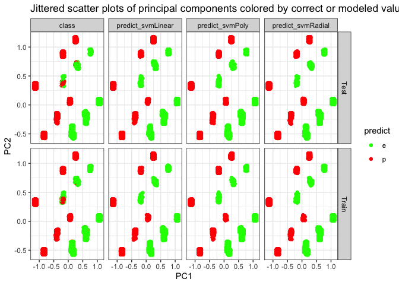

```r
M_mushrooms$predict_svmLinear <- predict(
  object = train_svmLinear,
  newdata = M_mushrooms %>%
    dplyr::select(
      odor,spore_print_color,ring_type,gill_color,gill_size
    )
)
M_mushrooms$predict_svmPoly <- predict(
  object = train_svmPoly,
  newdata = M_mushrooms %>%
    dplyr::select(
      odor,spore_print_color,ring_type,gill_color,gill_size
    )
)
M_mushrooms$predict_svmRadial <- predict(
  object = train_svmRadial,
  newdata = M_mushrooms %>%
    dplyr::select(
      odor,spore_print_color,ring_type,gill_color,gill_size
    )
)
M_mushrooms[,c("PC1","PC2")] <- prcomp(
  x = M_mushrooms %>%
    dplyr::select(
      odor,spore_print_color,ring_type,gill_color,gill_size
    )
)$x[,c("PC1","PC2")]
M_mushrooms %>%
  dplyr::select(
    train_test,
    PC1,PC2,
    class,
    predict_svmLinear,predict_svmPoly,predict_svmRadial
  ) %>%
  tidyr::gather(key = "model",value = "predict",class,predict_svmLinear,predict_svmPoly,predict_svmRadial) %>%
  ggplot() +
  aes(x = PC1,y = PC2,color = predict) +
  geom_jitter(width = 0.05, height = 0.05) +
  geom_point() +
  facet_grid(train_test ~ model) +
  scale_color_manual(values = c("green","red")) +
  theme_bw() +
  labs(
    title = "Jittered scatter plots of principal components colored by correct or modeled value"
  )
```

class is the target variable of the actual original data. In the predictions we can see solid colored groups which is what we want for good classification, not a mixture of colors oer group.

### Interpreting confusion matrix

```r
M_predict <- M_mushrooms %>%
  dplyr::select(
    train_test,
    class,
    predict_svmLinear,predict_svmPoly,predict_svmRadial
  ) %>%
  tidyr::gather(key = "model",value = "predict",predict_svmLinear,predict_svmPoly,predict_svmRadial)
M_predict %>%
  split(
    f = list(
      train_test = M_predict$train_test,
      model = M_predict$model
    )
  ) %>%
  lapply(
    FUN = function(dataframe) caret::confusionMatrix(
      data = factor(
        x = dataframe$predict,
        levels = c("p","e")
      ),
      reference = factor(
        x = dataframe$class,
        levels = c("p","e")
      )
    )
  )
```

```
## $Test.predict_svmLinear
## Confusion Matrix and Statistics
##
##           Reference
## Prediction    p    e
##          p 1930    0
##          e   59 2135
##
##                Accuracy : 0.986
##                  95% CI : (0.982, 0.989)
##     No Information Rate : 0.518
##     P-Value [Acc > NIR] : < 0.0000000000000002
##
##                   Kappa : 0.971
##
##  Mcnemar's Test P-Value : 0.0000000000000432
##
##             Sensitivity : 0.970
##             Specificity : 1.000
##          Pos Pred Value : 1.000
##          Neg Pred Value : 0.973
##              Prevalence : 0.482
##          Detection Rate : 0.468
##    Detection Prevalence : 0.468
##       Balanced Accuracy : 0.985
##
##        'Positive' Class : p
##
##
## $Train.predict_svmLinear
## Confusion Matrix and Statistics
##
##           Reference
## Prediction    p    e
##          p 1866    0
##          e   61 2073
##
##                Accuracy : 0.985
##                  95% CI : (0.98, 0.988)
##     No Information Rate : 0.518
```

[output cut: 118 more lines]

```
##                   Kappa : 0.969
##
##  Mcnemar's Test P-Value : 0.0000000000000156
##
##             Sensitivity : 0.968
##             Specificity : 1.000
##          Pos Pred Value : 1.000
##          Neg Pred Value : 0.971
##              Prevalence : 0.482
##          Detection Rate : 0.467
##    Detection Prevalence : 0.467
##       Balanced Accuracy : 0.984
##
##        'Positive' Class : p
##
```

For the test set using the linear kernel, we can see that when it was poisonous, we predicted edible 59 times. From the 3 kernels used, the one with the lowest wrong predictions(predicting edible whenn its poisnous) from the test set is what we want.

# Conclusion

Support Vector Machines, while conceptually straightforward, offer robust performance in both linear and non-linear scenarios. Their versatility, especially when paired with the kernel trick, makes them indispensable in the world of machine learning.

# Homework

1. Implement an SVM on a dataset of your choice. Try different kernels and compare their performance. Which kernel gave the best results?
2. How does the parameter $C$ in the soft margin SVM affect the model’s performance? Experiment with different values on your dataset and discuss your observations.
3. With your chosen dataset, compare the performance of SVM against another classifier. Which performs better and why?
4. Extend the SVM model to handle multi-class classification problems. How does the model performance change when increasing the number of classes?
5. Introduce noise into your dataset. How resilient is the SVM model to this noise? Experiment with both hard and soft margin SVMs and discuss the implications.

Remember, the key to mastering SVMs is hands-on experimentation. Happy coding!